# Temporal bisection is influenced by ensemble statistics of the stimulus set (Data Analysis Report)

Xiuna Zhu

12 Februar 2019

```r
mDist <-  dat_all %>% dplyr::group_by(NSub, cond) %>%
  summarise(m_cDur = mean(curDur), n = dplyr::n(),
            sd_Dur = sd(curDur),
            gm_Dur = gm_mean(curDur),
            cDur_se = sd(curDur)/sqrt(n-1))
mDist
```

| NSub | cond | m_cDur | n | sd_Dur | gm_Dur | cDur_se |
| --- | --- | --- | --- | --- | --- | --- |
| 1 | PS | 888.2857 | 336 | 401.3319 | 800.2084 | 21.92710 |
| 1 | NS | 1112.0000 | 336 | 401.5126 | 1018.4500 | 21.93698 |
| 1 | DF | 800.0000 | 448 | 346.7974 | 727.5822 | 16.40296 |
| 1 | AF | 1200.0000 | 448 | 346.7974 | 1137.7346 | 16.40296 |
| 1 | U-shaped | 925.0000 | 288 | 491.3893 | 781.2750 | 29.00579 |
| 1 | I T-shaped | 925.0000 | 288 | 175.3046 | 906.4752 | 10.34790 |
| 2 | PS | 888.2857 | 336 | 401.3319 | 800.2084 | 21.92710 |
| 2 | NS | 1112.0000 | 336 | 401.5126 | 1018.4500 | 21.93698 |
| 2 | DF | 800.0000 | 448 | 346.7974 | 727.5822 | 16.40296 |
| 2 | AF | 1200.0000 | 448 | 346.7974 | 1137.7346 | 16.40296 |

[output cut: 80 more lines]

# Experiment 1

positive skew condition (400, 504, 636, 800, 1008, 1270, and 1600 ms)

negative skew condition (400, 730, 992, 1200, 1366, 1496, and 1600 ms)

## Range Frequency Theory

To understand the pattern of results concerning schifts in the temporal bisection point, We have to check the distribution of stimuli within the sets firstly.

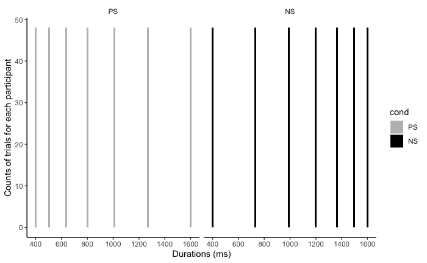

```r
sumfreq_exp1_sub1 <-  dat_exp1 %>% filter(NSub == 1) %>% group_by(cond, curDur) %>% summarise(count = n())
count_exp1 <- sum(sumfreq_exp1_sub1$count)/2
sumfreq_exp1_sub1$exp <- 'Exp1'
sumfreq_exp1_sub1$freq <- sumfreq_exp1_sub1$count/count_exp1*100

# rename columns
fig_exp1_sub1_dist <- ggplot(data=sumfreq_exp1_sub1, aes(x=curDur, y=count, fill=cond)) +
  geom_bar(stat="identity", position=position_dodge()) +
  #geom_smooth(method="loess",se = FALSE)+
  xlab('Durations (ms)') + ylab('Counts of trials for each participant') +
  scale_x_continuous(breaks=seq(0, 1600, 200)) +
  scale_color_manual(values = c('gray','black')) +
  scale_fill_manual(values = c('gray','black')) +mytheme+ facet_wrap(~cond)

fig_exp1_sub1_dist
```

## plot the distribution of stimulus set

```r
mDist_exp1 <-  dat_exp1 %>% filter(NSub == 1) %>% dplyr::group_by(cond) %>%
  summarise(m_cDur = mean(curDur), n = dplyr::n(),
            cDur_se = sd(curDur)/sqrt(n-1))
mDist_exp1
```

| cond | m_cDur | n | cDur_se |
| --- | --- | --- | --- |
| PS | 888.2857 | 336 | 21.92710 |
| NS | 1112.0000 | 336 | 21.93698 |

```r
plot_mDist_exp1 <- ggplot(mDist_exp1,aes(cond, m_cDur, color = cond, fill = cond))+
  geom_bar(stat='identity') +
  geom_errorbar(aes(ymin = m_cDur - cDur_se, ymax = m_cDur + cDur_se), width =0.5) +
  labs(x = " ", y = "Mean of Durations (ms)") +
  scale_color_manual(values = c('gray','black')) +
  scale_fill_manual(values = c('gray','black')) +
  theme(legend.position = "none", legend.title = element_blank())+
  theme(panel.grid.major=element_line(colour=NA))+
  theme(axis.text.y = element_text(size=26,colour = "black"),
        axis.text.x   = element_text(size=26, colour = "black"),
        axis.title.y  = element_text(size=26, colour = "black"),
        axis.title.x  = element_text(size=26, colour = "black"),
        panel.background = element_blank(),
        panel.grid.major = element_blank(),
        panel.grid.minor = element_blank(),
        axis.line = element_line(colour = "black"))

plot_mDist_exp1
```

## fit psychometric functions

```r
fits_exp1 = quickpsy(dat_exp1, x = curDur, k =RP, prob = .5,
                     grouping = .(cond, NSub), thresholds = FALSE)
head(fits_exp1$thresholds)
```

```r
fits_exp1_all = quickpsy(dat_exp1, x = curDur, k =RP, prob = .5, grouping = .(cond))
fits_exp1_all
```

```r
# plot fitted function
plot_fit_exp1 <- plot(fits_exp1_all) +
  labs(x = "Durations (ms)", y = "Proportion of 'Long' responses") +
  scale_color_manual(values = c('gray','black')) +
  scale_fill_manual(values = c('gray','black')) +
  theme(legend.position = c(0.7, 0.2), legend.title = element_blank())

plot_fit_exp1
```

```r
aic(fits_exp1_all)
```

```r
ypred(fits_exp1_all)
```

```r
exp1_all_thres<- fits_exp1_all$thresholds
exp1_all_thres$slope = 3/exp(exp1_all_thres$thre/1000) #slope
exp1_all_thres
```

```r
exp1_thres<- fits_exp1$thresholds
exp1_thres$slope = 3/exp(exp1_thres$thre/1000) #slope
exp1_thres
```

## list all of the parameter for each subjects

```r
par_exp1 = fits_exp1$par %>%
  dplyr::select(-parinf,-parsup) %>%
  spread(parn, par) %>%
  rename(pse =p1, jnd = p2)  # rename columns
par_exp1$slope = 3/exp(par_exp1$jnd/1000) #slope

par_exp1
```

```r
mpars_exp1 = par_exp1%>%
  group_by(cond) %>%
  summarise(m_pse = mean(pse), m_jnd = mean(jnd),  m_slope = mean(slope), n = n(),
            pse_se = sd(pse)/sqrt(n-1),
            jnd_se = sd(jnd)/sqrt(n-1),
            slope_se = sd(slope)/sqrt(n-1))

mpars_exp1
```

List all of the parameters for exp1 and export data for JASP

```r
exp1_jasp <- par_exp1%>%
  unite(pse.jnd.slope, pse, jnd, slope)%>%
  spread(cond, pse.jnd.slope)%>%
  separate(`PS`, c("PSC_pse", "PSC_jnd","PSC_slope"), sep = "_")%>%
  separate(`NS`, c("NSC_pse", "NSC_jnd","NSC_slope"), sep = "_")

exp1_jasp
```

## plot PSE

```r
plot_pse_exp1 <- ggplot(mpars_exp1,aes(cond, m_pse, color = cond, fill = cond))+
  geom_bar(stat='identity') +
  geom_errorbar(aes(ymin = m_pse - pse_se, ymax = m_pse + pse_se), width =0.5) +
  geom_signif(comparisons=list(c("PS", "NS")), annotations="*", y_position = 1150, tip_length = 0, vjust=0.4, color = 'black') +
  labs(x = " ", y = "Mean PSE (ms)") +
  coord_cartesian(ylim = c(0,1300)) +
  scale_color_manual(values = c('gray','black')) +
  scale_fill_manual(values = c('gray','black')) +
  theme(legend.position = "none")

plot_pse_exp1
```

```r
plot_pse_exp1_box <- ggplot(par_exp1,aes(x=cond, y=pse, color = cond))+
  geom_boxplot() +
  geom_jitter(position=position_jitter(0.2))+
  geom_signif(comparisons=list(c("PS", "NS")), annotations="*", y_position = 1350, tip_length = 0, vjust=0.4, color = 'black') +
  labs(x = " ", y = "Mean PSE (ms)") +
  coord_cartesian(ylim = c(500,1400)) +
  scale_color_manual(values = c('gray','black')) +
  scale_fill_manual(values = c('gray','black')) +
  theme(legend.position = "none")

plot_pse_exp1_box
```

## plot JND

```r
plot_jnd_exp1_box <- ggplot(par_exp1,aes(x=cond, y=jnd, color = cond))+
  geom_boxplot() +
  geom_jitter(position=position_jitter(0.2))+
  labs(x = " ", y = "Mean JND (ms)") +
  coord_cartesian(ylim = c(80,380))+
  scale_color_manual(values = c('gray','black')) +
  scale_fill_manual(values = c('gray','black')) + theme(legend.position = "none")

plot_jnd_exp1_box
```

```r
plot_jnd_exp1 <- ggplot(mpars_exp1,aes(cond, m_jnd, color = cond, fill = cond))+
  geom_bar(stat='identity') +
  geom_errorbar(aes(ymin = m_jnd - jnd_se, ymax = m_jnd + jnd_se), width =0.5) +
  labs(x = " ", y = "Mean JND (ms)") +
  coord_cartesian(ylim = c(0,400))+
  scale_color_manual(values = c('gray','black')) +
  scale_fill_manual(values = c('gray','black')) + theme(legend.position = "none")

plot_jnd_exp1
```

## ANOVA and T-test

```r
Anova_exp1_pse<- ezANOVA(data = par_exp1, dv= pse, wid=NSub, within=.(cond))
Anova_exp1_pse
```

```r
Anova_exp1_jnd<- ezANOVA(data = par_exp1, dv= jnd, wid=NSub, within=.(cond))
Anova_exp1_jnd
```

```r
Anova_exp1_slope<- ezANOVA(data = par_exp1, dv= slope, wid=NSub, within=.(cond))
Anova_exp1_slope
```

# Experiment 2

## Range Frequency Theory

A particular focus is the distribution of stimuli within the sets to be judged. To understand the pattern of results concerning schifts in the temporal bisection point, We have to check the frequency of the sets firstly.

```r
sumfreq_exp2_sub1 <-  dat_exp2 %>% filter(NSub == 1) %>% group_by(cond, curDur) %>% summarise(count = n())
count_exp2 <- sum(sumfreq_exp2_sub1$count)/2
sumfreq_exp2_sub1$exp <- 'Exp2'
sumfreq_exp2_sub1$freq <- sumfreq_exp2_sub1$count/count_exp2*100
fig_exp2_sub1_dist <- ggplot(data=sumfreq_exp2_sub1, aes(x=curDur, y=count, fill=cond)) +
  geom_bar(stat="identity", position=position_dodge()) +
  xlab('Durations (ms)') + ylab('Counts of trials for each participant') +
  scale_x_continuous(breaks=seq(0, 1600, 200)) +
  scale_color_manual(values = c('gray','black')) +
  scale_fill_manual(values = c('gray','black')) +mytheme

fig_exp2_sub1_dist
```

```r
mDist_exp2 <-  dat_exp2 %>% filter(NSub == 1) %>% dplyr::group_by(cond) %>%
  summarise(m_cDur = mean(curDur), n = dplyr::n(),
            cDur_se = sd(curDur)/sqrt(n-1))
mDist_exp2
```

| cond | m_cDur | n | cDur_se |
| --- | --- | --- | --- |
| DF | 800 | 448 | 16.40296 |
| AF | 1200 | 448 | 16.40296 |

```r
plot_mDist_exp2 <- ggplot(mDist_exp2,aes(cond, m_cDur, color = cond, fill = cond))+
  geom_bar(stat='identity') +
  geom_errorbar(aes(ymin = m_cDur - cDur_se, ymax = m_cDur + cDur_se), width =0.5) +
  #geom_text(aes(label=paste("(",m_cDur,",",round(cDur_se),")") ),size=8, hjust=0.5, vjust=-2, color = 'black')+
  labs(x = " ", y = " ") +
  #coord_cartesian(ylim = c(0,1600))+
  scale_color_manual(values = c('gray','black')) +
  scale_fill_manual(values = c('gray','black')) +
  theme(legend.position = "none", legend.title = element_blank())+
  theme(panel.grid.major=element_line(colour=NA))+
  theme(axis.text.y = element_text(size=26,colour = "black"),
        axis.text.x   = element_text(size=26, colour = "black"),
        axis.title.y  = element_text(size=26, colour = "black"),
        axis.title.x  = element_text(size=26, colour = "black"),
        panel.background = element_blank(),
        panel.grid.major = element_blank(),
        panel.grid.minor = element_blank(),
        axis.line = element_line(colour = "black")
  )

plot_mDist_exp2
```

## Fit psychometric functions

```r
fits_exp2 = quickpsy(dat_exp2, x = curDur, k =RP, prob = .5, grouping = .(cond, NSub))
```

```r
fits_exp2_all = quickpsy(dat_exp2, x = curDur, k =RP,
                         grouping = .(cond))
fits_exp2_all
```

```r
# plot fitted function
plot_fit_exp2 <- plot(fits_exp2_all) +
  labs(x = "Durations (ms)", y = "Proportion of 'Long' responses") +
  scale_color_manual(values = c('gray','black')) +
  scale_fill_manual(values = c('gray','black')) +
  theme(legend.position = c(0.7, 0.2), legend.title = element_blank())

plot_fit_exp2
```

## Average fitted paramters and plot

```r
par_exp2 = fits_exp2$par %>%
  dplyr::select(-parinf,-parsup) %>%
  spread(parn, par) %>%
  rename(pse =p1, jnd = p2)  # rename columns

par_exp2$slope = 3/exp(par_exp2$pse/1000) #add slope

par_exp2
```

```r
mpse_exp2 = par_exp2%>%
  group_by(cond) %>%
  summarise(m_pse = mean(pse), m_jnd = mean(jnd), m_slope = mean(slope), n = n(),
            pse_se = sd(pse)/sqrt(n-1),
            jnd_se = sd(jnd)/sqrt(n-1),
            slope_se = sd(slope)/sqrt(n-1))
mpse_exp2
```

## Export for JASP

List all of the parameters for Exp2 and export data for JASP

```r
exp2_jasp <- par_exp2%>%
  unite(pse.jnd.slope, pse, jnd, slope)%>%
  spread(cond, pse.jnd.slope)%>%
  separate(DF, c("DF_pse", "DF_jnd","DF_slope"), sep = "_")%>%
  separate(AF, c("AF_pse", "AF_jnd", "AF_slope"), sep = "_")

exp2_jasp
```

## plot PSE

```r
plot_pse_exp2 <- ggplot(mpse_exp2,aes(cond, m_pse, color = cond, fill = cond))+
  geom_bar(stat='identity') +
  geom_errorbar(aes(ymin = m_pse - pse_se, ymax = m_pse + pse_se), width =0.5) +
  geom_signif(comparisons=list(c("DF", "AF")), annotations="***", y_position = 1250, tip_length = 0, vjust=0.4, color = 'black') +
  labs(x = " ", y = "Mean PSE (ms)") +
  coord_cartesian(ylim = c(0,1300))+
  scale_color_manual(values = c('gray','black')) +
  scale_fill_manual(values = c('gray','black')) +
  theme(legend.position = "none")

plot_pse_exp2
```

```r
plot_pse_exp2_box <- ggplot(par_exp2,aes(x=cond, y=pse, color = cond))+
  geom_boxplot() +
  geom_jitter(position=position_jitter(0.2))+
  geom_signif(comparisons=list(c("DF", "AF")), annotations="***", y_position = 1450, tip_length = 0, vjust=0.4, color = 'black') +
  labs(x = " ", y = "Mean PSE (ms)") +
  coord_cartesian(ylim = c(500,1500))+
  scale_color_manual(values = c('gray','black')) +
  scale_fill_manual(values = c('gray','black')) +
  theme(legend.position = "none")

plot_pse_exp2_box
```

## plot JND

```r
plot_jnd_exp2 <- ggplot(mpse_exp2,aes(cond, m_jnd, color = cond, fill = cond))+
  geom_bar(stat='identity') +
  geom_errorbar(aes(ymin = m_jnd - jnd_se, ymax = m_jnd + jnd_se), width =0.5) +
  geom_signif(comparisons=list(c("DF", "AF")), annotations="***", y_position = 330, tip_length = 0, vjust=0.4, color = 'black') +
  labs(x = " ", y = "Mean JND (ms)") +
  coord_cartesian(ylim = c(0,350))+
  scale_color_manual(values = c('gray','black')) +
  scale_fill_manual(values = c('gray','black')) +
  theme(legend.position = "none")

plot_jnd_exp2
```

```r
plot_jnd_exp2_box <- ggplot(par_exp2,aes(x=cond, y=jnd, color = cond))+
  geom_boxplot() +
  geom_jitter(position=position_jitter(0.2)) +
  geom_signif(comparisons=list(c("DF", "AF")), annotations="***", y_position = 310, tip_length = 0, vjust=0.4, color = 'black') +
  labs(x = " ", y = "Mean JND (ms)") +
  coord_cartesian(ylim = c(80,330))+
  scale_color_manual(values = c('gray','black')) +
  scale_fill_manual(values = c('gray','black')) +
  theme(legend.position = "none")

plot_jnd_exp2_box
```

## ANOVA

```r
Anova_exp2_pse <- ezANOVA(data = par_exp2, dv= pse, wid=NSub, within=.(cond))
Anova_exp2_pse
```

```r
Anova_exp2_jnd <- ezANOVA(data = par_exp2, dv= jnd, wid=NSub, within=.(cond))
Anova_exp2_jnd
```

```r
Anova_exp2_slope <- ezANOVA(data = par_exp2, dv= slope, wid=NSub, within=.(cond))
Anova_exp2_slope
```

# Experiment 3

## Range Frequency Theory

To understand the pattern of results concerning schifts in the temporal bisection point, We have to check the distribution of stimuli within the sets firstly.

```r
sumfreq_exp3_sub1 <-  dat_exp3 %>% filter(NSub ==1) %>% group_by(cond, curDur) %>% summarise(count = n())
# rename columns
sumfreq_exp3_sub1$exp <- 'Exp3'
count_exp3 <- sum(sumfreq_exp3_sub1$count)/2
sumfreq_exp3_sub1$freq <- sumfreq_exp3_sub1$count/count_exp3*100

fig_exp3_sub1_dist <- ggplot(data=sumfreq_exp3_sub1, aes(x=curDur, y=freq, fill=cond)) +
  geom_bar(stat="identity", position=position_dodge()) +
  xlab('Durations (ms)') + ylab('Counts of trials for each participant') +
  scale_x_continuous(breaks=seq(0, 1600, 200)) +
  scale_color_manual(values = c('gray','black')) +
  scale_fill_manual(values = c('gray','black')) +mytheme

fig_exp3_sub1_dist
```

```r
mDist_exp3 <-  dat_exp3 %>% filter(NSub == 1) %>% dplyr::group_by(cond) %>%
  summarise(m_cDur = mean(curDur), n = dplyr::n(),
            cDur_se = sd(curDur)/sqrt(n-1))
mDist_exp3
```

| cond | m_cDur | n | cDur_se |
| --- | --- | --- | --- |
| U-shaped | 925 | 288 | 29.00579 |
| I T-shaped | 925 | 288 | 10.34790 |

```r
plot_mDist_exp3 <- ggplot(mDist_exp3,aes(cond, m_cDur, color = cond, fill = cond))+
  geom_bar(stat='identity') +
  geom_errorbar(aes(ymin = m_cDur - cDur_se, ymax = m_cDur + cDur_se), width =0.5) +
  labs(x = " ", y = " ") +
  scale_color_manual(values = c('gray','black')) +
  scale_fill_manual(values = c('gray','black')) +
  theme(legend.position = "none", legend.title = element_blank())+
  theme(panel.grid.major=element_line(colour=NA))+
  theme(axis.text.y = element_text(size=26,colour = "black"),
        axis.text.x   = element_text(size=26, colour = "black"),
        axis.title.y  = element_text(size=26, colour = "black"),
        axis.title.x  = element_text(size=26, colour = "black"),
        panel.background = element_blank(),
        panel.grid.major = element_blank(),
        panel.grid.minor = element_blank(),
        axis.line = element_line(colour = "black"))
plot_mDist_exp3
```

## Fit psychometric functions

```r
fits_exp3 = quickpsy(dat_exp3, x = curDur, k =RP, prob = .5,
                     grouping = .(cond, NSub), thresholds = FALSE)
```

```r
fits_exp3_all = quickpsy(dat_exp3, x = curDur, k =RP,
                         grouping = .(cond), thresholds = FALSE)
fits_exp3_all
```

```r
# plot fitted function
plot_fit_exp3 <- plot(fits_exp3_all) +
  labs(x = "Durations (ms)", y = "Proportion of 'Long' responses") +
  scale_color_manual(values = c('gray','black')) +
  scale_fill_manual(values = c('gray','black')) +
  theme(legend.position = c(0.7, 0.2), legend.title = element_blank())

plot_fit_exp3
```

## List all of the parameter for each subjects

```r
par_exp3 = fits_exp3$par %>%
  dplyr::select(-parinf,-parsup) %>%
  spread(parn, par) %>%
  rename(pse =p1, jnd = p2)  # rename columns

par_exp3$slope = 3/exp(par_exp3$pse/1000) #add slope

par_exp3
```

```r
mpars_exp3 = par_exp3%>%
  group_by(cond) %>%
  summarise(m_pse = mean(pse), m_jnd = mean(jnd), m_slope = mean(slope), n = n(),pse_se = sd(pse)/sqrt(n-1), jnd_se = sd(jnd)/sqrt(n-1),slope_se = sd(slope)/sqrt(n-1))

mpars_exp3
```

##Export for JASP

List all of the parameters for Exp3 and export data for JASP

```r
exp3_jasp <- par_exp3%>%
  unite(pse.jnd.slope, pse, jnd, slope)%>%
  spread(cond, pse.jnd.slope)%>%
  separate(`U-shaped`, c("U_pse", "U_jnd", "U_slope"), sep = "_")%>%
  separate(`I T-shaped`, c("B_pse", "B_jnd", "B_slope"), sep = "_")

exp3_jasp
```

## plot PSE

```r
plot_pse_exp3 <- ggplot(mpars_exp3,aes(cond, m_pse, color = cond, fill = cond))+
  geom_bar(stat='identity') +
  geom_errorbar(aes(ymin = m_pse - pse_se, ymax = m_pse + pse_se), width =0.5) +
  coord_cartesian(ylim = c(0,1300)) +
  labs(x = " ", y = "Mean PSE (ms)") +
  scale_color_manual(values = c('gray','black')) +
  scale_fill_manual(values = c('gray','black')) +
  theme(legend.position = "none", legend.title = element_blank())
plot_pse_exp3
```

```r
plot_pse_exp3_box <- ggplot(par_exp3,aes(x=cond, y=pse, color = cond))+
  geom_boxplot() +
  geom_jitter(position=position_jitter(0.2))+
  coord_cartesian(ylim = c(500,1300)) +
  labs(x = " ", y = "Mean PSE (ms)") +
  scale_color_manual(values = c('gray','black')) +
  scale_fill_manual(values = c('gray','black')) +
  theme(legend.position = "none", legend.title = element_blank())
plot_pse_exp3_box
```

## plot JND

```r
plot_jnd_exp3 <- ggplot(mpars_exp3,aes(cond, m_jnd, color = cond, fill = cond))+
  geom_bar(stat='identity') +
  geom_errorbar(aes(ymin = m_jnd - jnd_se, ymax = m_jnd + jnd_se), width =0.5) +
  coord_cartesian(ylim = c(0,300))+
  geom_signif(comparisons=list(c("U-shaped", "I T-shaped")), annotations="***", y_position = 250, tip_length = 0, vjust=0.4, color = 'black') +
  labs(x = " ", y = "Mean JND (ms)") +
  scale_color_manual(values = c('gray','black')) +
  scale_fill_manual(values = c('gray','black')) +
  theme(legend.position = "none")
plot_jnd_exp3
```

```r
plot_jnd_exp3_box <- ggplot(par_exp3,aes(x=cond, y=jnd, color = cond))+
  geom_boxplot() +
  geom_jitter(position=position_jitter(0.2))+
  coord_cartesian(ylim = c(0,400))+
  geom_signif(comparisons=list(c("U-shaped", "I T-shaped")), annotations="***", y_position = 380, tip_length = 0, vjust=0.4, color = 'black') +
  labs(x = " ", y = "Mean JND (ms)") +
  scale_color_manual(values = c('gray','black')) +
  scale_fill_manual(values = c('gray','black')) +
  theme(legend.position = "none")
plot_jnd_exp3_box
```

## ANOVA

```r
Anova_exp3_pse<- ezANOVA(data = par_exp3, dv= pse, wid=NSub, within=.(cond))
Anova_exp3_pse
```

```r
Anova_exp3_jnd<- ezANOVA(data = par_exp3, dv= jnd, wid=NSub, within=.(cond))
Anova_exp3_jnd
```

```r
Anova_exp3_slope<- ezANOVA(data = par_exp3, dv= slope, wid=NSub, within=.(cond))
Anova_exp3_slope
```

# figures in manuscript

## plot figure 1 in manuscript

```r
fig_exp1_sub1_dist2 <- ggplot(data=sumfreq_exp1_sub1, aes(x=curDur, y=freq, fill=cond, color = cond)) +
  geom_bar(stat="identity", position=position_dodge(),width = 3) +
  geom_point()+
  xlab('') + ylab('Prob. (%)') +
  scale_x_continuous(breaks=seq(0, 1600, 200)) +
  scale_y_continuous(breaks=seq(0, 50, 5)) +
  scale_color_manual(values = c('gray','black')) +
  scale_fill_manual(values = c('gray','black')) +
  theme(legend.position = "none", legend.title = element_blank()) + facet_wrap(~cond)

fig_exp2_sub1_dist_2 <- ggplot(data=sumfreq_exp2_sub1, aes(x=curDur, y=freq, fill=cond, color = cond)) +
  geom_bar(stat="identity", position=position_dodge(), width = 3) +
  geom_point()+
  scale_x_continuous(breaks=seq(0, 1600, 200)) +
  scale_y_continuous(breaks=seq(0, 50, 10)) +
  xlab('') + ylab('Prob. (%)') +
  scale_color_manual(values = c('gray','black')) +
  scale_fill_manual(values = c('gray','black')) +
  theme(legend.position = 'none', legend.title = element_blank()) + facet_wrap(~cond)

fig_exp3_sub1_dist2 <- ggplot(data=sumfreq_exp3_sub1, aes(x=curDur, y=freq, fill=cond, color = cond)) +
  geom_bar(stat="identity", position=position_dodge(), width = 3) +
  geom_point()+
  xlab('Durations (ms)') + ylab('Prob. (%)') +
  scale_x_continuous(breaks=seq(0, 1600, 200)) +
  scale_y_continuous(breaks=seq(0, 50, 10)) +
  scale_color_manual(values = c('gray','black')) +
  scale_fill_manual(values = c('gray','black')) +
  theme(legend.position = "none", legend.title = element_blank())+ facet_wrap(~cond)

plot_grid(fig_exp1_sub1_dist2, fig_exp2_sub1_dist_2, fig_exp3_sub1_dist2,  ncol = 1, labels = c("A", "B", "C"), rel_heights = c(3,3,3))
```

## plot Figure 2 in manuscript

```r
plot_grid(plot_fit_exp1, plot_pse_exp1, plot_jnd_exp1,  nrow = 1, labels = c("A", "B", "C"), rel_widths = c(4,3,3))
```

```r
fig2 <- plot_grid(plot_fit_exp1, plot_pse_exp1_box, plot_jnd_exp1_box,  nrow = 1, labels = c("A", "B", "C"), rel_widths = c(4,3,3))
```

## plot Figure 3 in manuscript

```r
plot_grid(plot_fit_exp2, plot_pse_exp2, plot_jnd_exp2,  nrow = 1, labels = c("A", "B", "C"), rel_widths = c(4,3,3))
```

```r
fig3 <- plot_grid(plot_fit_exp2, plot_pse_exp2_box, plot_jnd_exp2_box,  nrow = 1, labels = c("A", "B", "C"), rel_widths = c(4,3,3))
```

## plot Figure 4 in manuscript

```r
plot_grid(plot_fit_exp3, plot_pse_exp3, plot_jnd_exp3,  nrow = 1, labels = c("A", "B", "C"), rel_widths = c(4,3,3))
```

```r
fig4 <- plot_grid(plot_fit_exp3, plot_pse_exp3_box, plot_jnd_exp3_box,  nrow = 1, labels = c("A", "B", "C"), rel_widths = c(4,3,3))
```

# Model Results

## load the Model result

```r
#customize theme
theme_new <- theme_bw() +
  theme(panel.border = element_blank(),
        panel.grid.major = element_blank(),
        panel.grid.minor = element_blank(),
        axis.line=element_line(colour="black"),
        strip.background = element_rect(color = "white", fill = "white"),
        panel.grid = element_blank())

models <- c('model1', 'model2','model3', 'model4','model5')
expDat <- list(dat_exp1, dat_exp2, dat_exp3)
#load the data and remove the outliers

par_observed <- rbind(rbind(par_exp1, par_exp2), par_exp3)
par_observed <- par_observed %>% filter(!((NSub == 10|NSub == 6 ) & (cond == 'AF'| cond =='DF')))%>% filter(!((NSub == 1) & (cond == 'PS'| cond =='NS')))
modelresults<- read.csv("../data/modelresults.csv")  %>% filter(!((NSub == 10|NSub == 6) & (cond == 'AF'| cond =='DF')))%>% filter(!((NSub == 1) & (cond == 'PS'| cond =='NS')))
```

```r
displayModellist <- c("Bisection Model",  "Spacing Model", "Ensemble Mean",  "Two-stage Ensemble Mean", "EDA")
#combine oberserved and predicated PSEs and JNDs
par_comb = left_join(modelresults, par_observed, by = c('NSub', 'cond'))
par_comb$errpse <- par_comb$PSEmap-par_comb$pse
par_comb$errjnd <- par_comb$JNDmap-par_comb$jnd
par_comb$model = factor(par_comb$model, labels = displayModellist)
head(par_comb)
```

```r
#calculate AIC and BIC
numParam <- 3
mpar_comb <- par_comb %>% dplyr::group_by(model, cond) %>%
  dplyr::summarise(sumerrpse=sum((errpse)^2), n=n(),
                   sumerrjnd=sum((errjnd)^2)) %>%
  dplyr::group_by(model, cond) %>%
  summarise(aicPse= 2 * numParam +  n*log(sumerrpse/n),
            bicPse = n*log(sumerrpse/n) + numParam*log(n),
            aicJnd= 2 * numParam +  n*log(sumerrjnd/n),
            bicJnd = n*log(sumerrjnd/n) + numParam*log(n), )

### show the mean in each model
m_par <- modelresults %>% group_by(model, cond, NSub) %>%
  summarise(xmean= mean(xmean), xmeanhat= mean(xmeanhat))  %>%
  group_by(model, cond) %>%
  summarise(xmean= mean(xmean), xmeanhat= mean(xmeanhat))
```

## plot figure 7 in manuscript

```r
par_comb <- arrange(transform(par_comb,
                              cond=factor(cond,levels=c("PS","DF","U-shaped","NS","AF","I T-shaped"))),cond)

cbp1 <- c( "#CC79A7", "#F0E442", "#0072B2", "#E69F00", "#D55E00")
plt_ErrorScatter = ggplot(par_comb, aes(errpse, errjnd, color = model, shape = model)) +
  geom_hline(yintercept = 0, linetype='dashed')+ geom_vline(xintercept = 0, linetype='dashed')+
  geom_point() +
  xlab('Prediction error in the PSEs (ms)')+ ylab('Prediction error in the JNDs (ms)')+
  scale_color_manual(values = cbp1) +
  scale_shape_manual(values=c(0, 1, 2, 8, 16))+
  facet_wrap(~cond)+
  theme_new+ theme(legend.position = 'top')

plt_ErrorScatter
```

## plot figure 6 in manuscript

```r
m_parcomb <- par_comb %>% dplyr::group_by(model, cond) %>%
  dplyr::summarise(mPSEmap=mean(PSEmap), pse = mean(pse), mJNDmap=mean(JNDmap),jnd = mean(jnd),
                   merrpse =mean(errpse), merrjnd = mean(errjnd),n=n(),
                   PSEmap_se = sd(PSEmap)/sqrt(n-1), JNDmap_se = sd(JNDmap)/sqrt(n-1),
                   errpse_se =sd(errpse)/sqrt(n-1), errjnd_se =sd(errjnd)/sqrt(n-1))

m_par_observed <- par_observed %>% dplyr::group_by(cond) %>%
  dplyr::summarise(mpse=mean(pse), mjnd= mean(jnd), n=n(),
                   pse_se =sd(pse)/sqrt(n-1), jnd_se =sd(jnd)/sqrt(n-1))
m_par_observed$mPSEmap<-m_par_observed$mpse
m_par_observed$mJNDmap<-m_par_observed$mjnd

m_parcomb2 <- arrange(transform(m_parcomb,
             cond=factor(cond,levels=c("PS","DF","U-shaped","NS","AF","I T-shaped"))),cond)


fig_estimation = ggplot(m_parcomb2, aes(x=mPSEmap, y=mJNDmap, color = model, shape = model)) +
  geom_point(data =m_par_observed, aes(x = mpse, y =mjnd, size=2), width =2, shape =16, alpha = 0.5,  color = 'black') +
  geom_point(data = par_comb, aes(x = pse, y =jnd), alpha = 0.25, color = 'lightgray', shape=16) +
  geom_point() +
  geom_errorbar(aes(ymax=mJNDmap+JNDmap_se, ymin=mJNDmap-JNDmap_se), size=0.6)+
  geom_errorbarh(aes(xmax=mPSEmap+PSEmap_se, xmin=mPSEmap-PSEmap_se),size=0.6)+
  ylab('Observed JNDs (ms)')+xlab('Observed PSEs (ms)') +
  scale_color_manual(values = cbp1) +
  scale_shape_manual(values=c(0, 1, 2, 8, 16))+
  theme_new+ theme(legend.position = 'top') +
  facet_wrap(.~cond,  ncol=3)+
  scale_size(guide = 'none')

fig_estimation
```